# Imputation of NHANES Data and Model Selection

Michael Conlin

2023-08-01

## Loading Data

Loading the NHANES data for exploration.

```r
library(NHANES)
# head(NHANES)
```

### Variable Selection

A look at changing Marijuana to RegularMarijuana and nPregnancies to nBabies:

```r
fit_null = lm(BMI ~ Age + Age1stBaby + AlcoholYear + Marijuana +
    BPSysAve + UrineVol1 + nPregnancies + Poverty + SleepHrsNight +
    Age:Age1stBaby + Age:AlcoholYear + Age:BPSysAve + Age:UrineVol1 +
    Age:nPregnancies + Age:SleepHrsNight,
  data = NHANES)
fit_change = lm(BMI ~ Age + Age1stBaby + AlcoholYear + RegularMarij +
    BPSysAve + UrineVol1 + nBabies + Poverty + SleepHrsNight +
    Age:Age1stBaby + Age:AlcoholYear + Age:BPSysAve + Age:UrineVol1 +
    Age:nBabies + Age:SleepHrsNight,
  data = NHANES)
summary(fit_null)
```

```
##
## Call:
## lm(formula = BMI ~ Age + Age1stBaby + AlcoholYear + Marijuana +
##     BPSysAve + UrineVol1 + nPregnancies + Poverty + SleepHrsNight +
##     Age:Age1stBaby + Age:AlcoholYear + Age:BPSysAve + Age:UrineVol1 +
##     Age:nPregnancies + Age:SleepHrsNight, data = NHANES)
##
## Residuals:
##    Min     1Q Median     3Q    Max
## -15.86  -4.55  -0.94   3.68  34.72
##
## Coefficients:
##                    Estimate Std. Error t value Pr(>|t|)
## (Intercept)       -3.919347  11.880186   -0.33  0.74154
## Age                0.592275   0.262826    2.25  0.02446 *
## Age1stBaby        -0.119909   0.233198   -0.51  0.60724
## AlcoholYear       -0.026421   0.015901   -1.66  0.09692 .
## MarijuanaYes       0.833730   0.448960    1.86  0.06362 .
## BPSysAve           0.226768   0.084392    2.69  0.00734 **
## UrineVol1         -0.008801   0.013397   -0.66  0.51136
## nPregnancies       2.584619   0.790896    3.27  0.00112 **
## Poverty           -0.571690   0.151805   -3.77  0.00018 ***
## SleepHrsNight      0.586792   0.834816    0.70  0.48229
## Age:Age1stBaby    -0.000852   0.005173   -0.16  0.86913
## Age:AlcoholYear    0.000249   0.000328    0.76  0.44850
## Age:BPSysAve      -0.002538   0.001799   -1.41  0.15875
## Age:UrineVol1      0.000204   0.000302    0.68  0.49976
## Age:nPregnancies  -0.055892   0.017728   -3.15  0.00167 **
## Age:SleepHrsNight -0.016783   0.018391   -0.91  0.36171
## ---
## Signif. codes:  0 '***' 0.001 '**' 0.01 '*' 0.05 '.' 0.1 ' ' 1
##
## Residual standard error: 6.69 on 932 degrees of freedom
##   (9052 observations deleted due to missingness)
## Multiple R-squared:  0.151,  Adjusted R-squared:  0.137
## F-statistic:   11 on 15 and 932 DF,  p-value: <2e-16
```

```r
summary(fit_change)
```

```
##
## Call:
## lm(formula = BMI ~ Age + Age1stBaby + AlcoholYear + RegularMarij +
##     BPSysAve + UrineVol1 + nBabies + Poverty + SleepHrsNight +
##     Age:Age1stBaby + Age:AlcoholYear + Age:BPSysAve + Age:UrineVol1 +
##     Age:nBabies + Age:SleepHrsNight, data = NHANES)
##
## Residuals:
##    Min     1Q Median     3Q    Max
## -16.47  -4.81  -0.85   3.66  35.14
##
## Coefficients:
##                    Estimate Std. Error t value Pr(>|t|)
## (Intercept)       -2.947853  12.469442   -0.24  0.81317
## Age                0.605596   0.277907    2.18  0.02957 *
## Age1stBaby        -0.082810   0.242388   -0.34  0.73270
## AlcoholYear       -0.025427   0.016074   -1.58  0.11402
## RegularMarijYes   -0.012473   0.567258   -0.02  0.98246
## BPSysAve           0.240249   0.084878    2.83  0.00475 **
## UrineVol1         -0.008018   0.013459   -0.60  0.55151
## nBabies            3.092903   1.421897    2.18  0.02987 *
## Poverty           -0.577854   0.153676   -3.76  0.00018 ***
## SleepHrsNight      0.222690   0.833699    0.27  0.78944
## Age:Age1stBaby    -0.001859   0.005368   -0.35  0.72921
## Age:AlcoholYear    0.000249   0.000331    0.75  0.45166
## Age:BPSysAve      -0.002891   0.001811   -1.60  0.11079
## Age:UrineVol1      0.000186   0.000303    0.61  0.53976
## Age:nBabies       -0.069385   0.031093   -2.23  0.02588 *
## Age:SleepHrsNight -0.009883   0.018409   -0.54  0.59148
## ---
## Signif. codes:  0 '***' 0.001 '**' 0.01 '*' 0.05 '.' 0.1 ' ' 1
##
## Residual standard error: 6.72 on 932 degrees of freedom
##   (9052 observations deleted due to missingness)
## Multiple R-squared:  0.142,  Adjusted R-squared:  0.129
## F-statistic: 10.3 on 15 and 932 DF,  p-value: <2e-16
```

The model is stronger with the original variable, so I will keep those.

Assessment of LittleInterest vs Depressed

```r
table(NHANES$LittleInterest, NHANES$Depressed)
```

```
##
##           None Several Most
##   None    4622     411   69
##   Several  519     501  110
##   Most      98      96  239
```

These seem to correlate strongly, so no advantage to changing

#### Add in additional possible helpful Variables

I added in Gender, Race1, Education, and MartialStatus.

```r
df_keep = data.frame(predictor = c('SurveyYr', 'Age', 'Age1stBaby', 'AlcoholYear', 'Marijuana', 'SmokeNow', 'HardDrugs', 'BPDiaAve', 'BPSysAve', 'PhysActiveDays', 'TVHrsDay', 'CompHrsDay', 'TotChol', 'Diabetes', 'UrineVol1', 'HealthGen', 'LittleInterest', 'nPregnancies',  'Poverty', 'SleepHrsNight', 'Gender', 'Race1', 'Education', 'MaritalStatus' ))
```

```r
nhanes_select = subset(NHANES, select =c(df_keep$predictor, "BMI"))
nrow(NHANES)
```

```
## [1] 10000
```

```r
ncol(NHANES)
```

```
## [1] 76
```

```r
nrow(nhanes_select)
```

```
## [1] 10000
```

```r
ncol(nhanes_select)
```

```
## [1] 25
```

We need to know which ones are categorical and turn them into factors

```r
nhanes_select$Marijuana = as.factor(nhanes_select$Marijuana)
nhanes_select$SmokeNow = as.factor(nhanes_select$SmokeNow)
nhanes_select$HardDrugs = as.factor(nhanes_select$HardDrugs)
nhanes_select$Diabetes = as.factor(nhanes_select$Diabetes)
nhanes_select$TVHrsDay = as.factor(nhanes_select$TVHrsDay)
nhanes_select$CompHrsDay = as.factor(nhanes_select$CompHrsDay)
nhanes_select$HealthGen = as.factor(nhanes_select$HealthGen)
nhanes_select$LittleInterest = as.factor(nhanes_select$LittleInterest)
nhanes_select$Gender = as.factor(nhanes_select$Gender)
nhanes_select$Race1 = as.factor(nhanes_select$Race1)
nhanes_select$Education = as.factor(nhanes_select$Education)
nhanes_select$MaritalStatus = as.factor(nhanes_select$MaritalStatus)
```

### Multiple Imputation of Data with `mice` Package

```r
if (!require(mice)) {
  install.packages("mice")
}
```

Here we will perform the imputation. Given the size of the data, this will take a bit of processing time.

```r
library(mice)
# perform the multiple imputation (5 datasets)
imp = mice(nhanes_select, seed = 420, m = 5, print = FALSE)
```

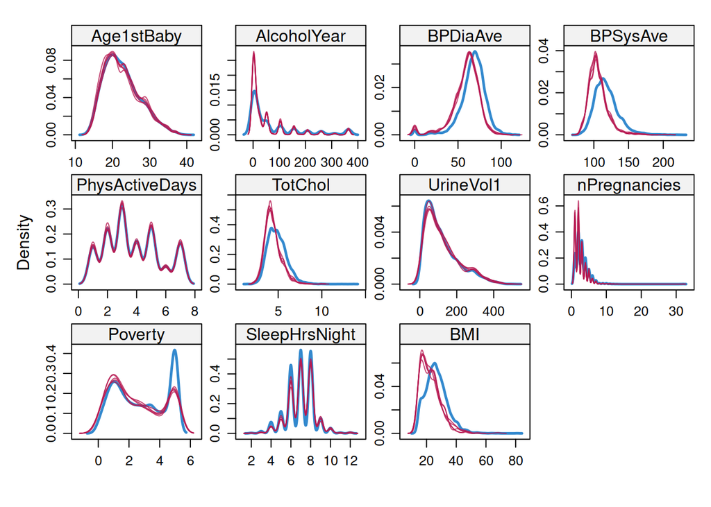

```r
# Compare the imputed variables red) and observed (blue)
densityplot(imp)
```

Now we build and run the stepwise process to select predictors. Notice that our 5 datasets with observed and imputed data are passed to the stepwise function using `with()` which in this case returns a `mira` object from the `mice` package.

```r
# build the stepwise workflow
scope <- list(upper = ~ Age +  Age1stBaby +  AlcoholYear +  Marijuana +  SmokeNow +  HardDrugs +  BPDiaAve +  BPSysAve +  PhysActiveDays +  TVHrsDay +  CompHrsDay +  TotChol +  Diabetes +  UrineVol1 +  HealthGen +  LittleInterest +  nPregnancies +   Poverty +  SleepHrsNight +  Gender +  Race1 +  Education +  MaritalStatus + Age:Age1stBaby +  Age:AlcoholYear +  Age:Marijuana +  Age:SmokeNow +  Age:HardDrugs +  Age:BPDiaAve +  Age:BPSysAve +  Age:PhysActiveDays  +  Age:CompHrsDay +  Age:TotChol +  Age:Diabetes +  Age:UrineVol1 +  Age:HealthGen +  Age:LittleInterest +  Age:nPregnancies +   Age:Poverty +  Age:SleepHrsNight +  Age:Gender +  Age:Race1 +  Age:Education +  Age:MaritalStatus,
             lower = ~ 1)
expr <- expression(f1 <- lm(log(BMI) ~ 1),
                  f2 <- step(f1, scope = scope, k = log(nrow(nhanes_select)), trace = 0))
# perform the stepwise selection with each of the 5 imputed datasets
fit <- with(imp, expr)

# count the votes for variables to keep
formulas <- lapply(fit$analyses, formula)
terms <- lapply(formulas, terms)
votes <- unlist(lapply(terms, labels))
table(votes)
```

```
## votes
##              Age     Age:BPDiaAve     Age:BPSysAve     Age:Diabetes
##                5                5                5                5
##       Age:Gender    Age:HealthGen Age:nPregnancies     Age:SmokeNow
##                2                4                3                5
##      Age:TotChol       Age1stBaby      AlcoholYear         BPDiaAve
##                1                5                5                5
##         BPSysAve       CompHrsDay         Diabetes           Gender
##                5                5                5                2
##        HardDrugs        HealthGen   LittleInterest        Marijuana
##                3                5                1                2
##     nPregnancies   PhysActiveDays          Poverty            Race1
##                3                5                1                5
##         SmokeNow          TotChol         TVHrsDay        UrineVol1
##                5                1                5                2
```

If we use the criterion of more than half of the datasets resulted in selection of a variable, we end up with:

lm(log(BMI) ~ Age + Age1stBaby + AlcoholYear + BPDiaAve + BPSysAve + BPSysAve + CompHrsDay + Diabetes + HardDrugs + HealthGen + nPregnancies + PhysActiveDays + Race1 + SmokeNow + TVHrsDay + Age:BPDiaAve + Age:BPSysAve + Age:Diabetes + Age:HealthGen + Age:nPregnancies + Age:SmokeNow

Lets see if we can trim out the variables with the lower vote counts (not selected with each imputed dataset)

```r
# remove Age:HealthGen
model_with = with(imp, lm(log(BMI) ~ Age + Age1stBaby + AlcoholYear + BPDiaAve +
                       BPSysAve + BPSysAve + CompHrsDay + Diabetes + HardDrugs +
                       HealthGen + nPregnancies + PhysActiveDays  + Race1 +
                       SmokeNow + TVHrsDay + Age:BPDiaAve + Age:BPSysAve +
                       Age:Diabetes + Age:HealthGen + Age:nPregnancies + Age:SmokeNow))
model_without = with(imp, lm(log(BMI) ~ Age + Age1stBaby + AlcoholYear + BPDiaAve +
                       BPSysAve + BPSysAve + CompHrsDay + Diabetes + HardDrugs +
                       HealthGen + nPregnancies + PhysActiveDays  + Race1 +
                       SmokeNow + TVHrsDay + Age:BPDiaAve + Age:BPSysAve +
                       Age:Diabetes + Age:nPregnancies + Age:SmokeNow))
anova(model_with, model_without)
```

```
##    test statistic df1   df2 dfcom   p.value    riv
##  1 ~~ 2     6.638   4 78.15  9960 0.0001187 0.5841
```

The p-value suggests that Age:HealthGen is worth keeping.

```r
# remove Age:nPregnancies
model_with = with(imp, lm(log(BMI) ~ Age + Age1stBaby + AlcoholYear + BPDiaAve +
                       BPSysAve + BPSysAve + CompHrsDay + Diabetes + HardDrugs +
                       HealthGen + nPregnancies + PhysActiveDays  + Race1 +
                       SmokeNow + TVHrsDay + Age:BPDiaAve + Age:BPSysAve +
                       Age:Diabetes + Age:HealthGen + Age:nPregnancies + Age:SmokeNow))
model_without = with(imp, lm(log(BMI) ~ Age + Age1stBaby + AlcoholYear + BPDiaAve +
                       BPSysAve + BPSysAve + CompHrsDay + Diabetes + HardDrugs +
                       HealthGen + nPregnancies + PhysActiveDays  + Race1 +
                       SmokeNow + TVHrsDay + Age:BPDiaAve + Age:BPSysAve +
                       Age:Diabetes + Age:HealthGen + Age:SmokeNow))
anova(model_with, model_without)
```

```
##    test statistic df1 df2 dfcom p.value   riv
##  1 ~~ 2     18.43   1   4  9960 0.01272 2.029
```

With a p-value of greater than 0.01, lets remove Age:nPregnancies

```r
# remove HardDrugs
model_with = with(imp, lm(log(BMI) ~ Age + Age1stBaby + AlcoholYear + BPDiaAve +
                       BPSysAve + BPSysAve + CompHrsDay + Diabetes + HardDrugs +
                       HealthGen + nPregnancies + PhysActiveDays  + Race1 +
                       SmokeNow + TVHrsDay + Age:BPDiaAve + Age:BPSysAve +
                       Age:Diabetes + Age:HealthGen + Age:SmokeNow))
model_without = with(imp, lm(log(BMI) ~ Age + Age1stBaby + AlcoholYear + BPDiaAve +
                       BPSysAve + BPSysAve + CompHrsDay + Diabetes +
                       HealthGen + nPregnancies + PhysActiveDays  + Race1 +
                       SmokeNow + TVHrsDay + Age:BPDiaAve + Age:BPSysAve +
                       Age:Diabetes + Age:HealthGen + Age:SmokeNow))
anova(model_with, model_without)
```

```
##    test statistic df1 df2 dfcom p.value   riv
##  1 ~~ 2     4.007   1   4  9961  0.1159 2.594
```

It also seems that HardDrugs is not needed in our model.

```r
# remove nPregnancies
model_with =with(imp, lm(log(BMI) ~ Age + Age1stBaby + AlcoholYear + BPDiaAve +
                       BPSysAve + BPSysAve + CompHrsDay + Diabetes +
                       HealthGen + nPregnancies + PhysActiveDays  + Race1 +
                       SmokeNow + TVHrsDay + Age:BPDiaAve + Age:BPSysAve +
                       Age:Diabetes + Age:HealthGen + Age:SmokeNow))
model_without = with(imp, lm(log(BMI) ~ Age + Age1stBaby + AlcoholYear + BPDiaAve +
                       BPSysAve + BPSysAve + CompHrsDay + Diabetes +
                       HealthGen + PhysActiveDays  + Race1 +
                       SmokeNow + TVHrsDay + Age:BPDiaAve + Age:BPSysAve +
                       Age:Diabetes + Age:HealthGen + Age:SmokeNow))
anova(model_with, model_without)
```

```
##    test statistic df1 df2 dfcom p.value   riv
##  1 ~~ 2      2.12   1   4  9962  0.2191 3.025
```

With a p-value greater than 0.01, we can safely remove nPregnacies.

### Consider log transformations of numerical measurements

BMI

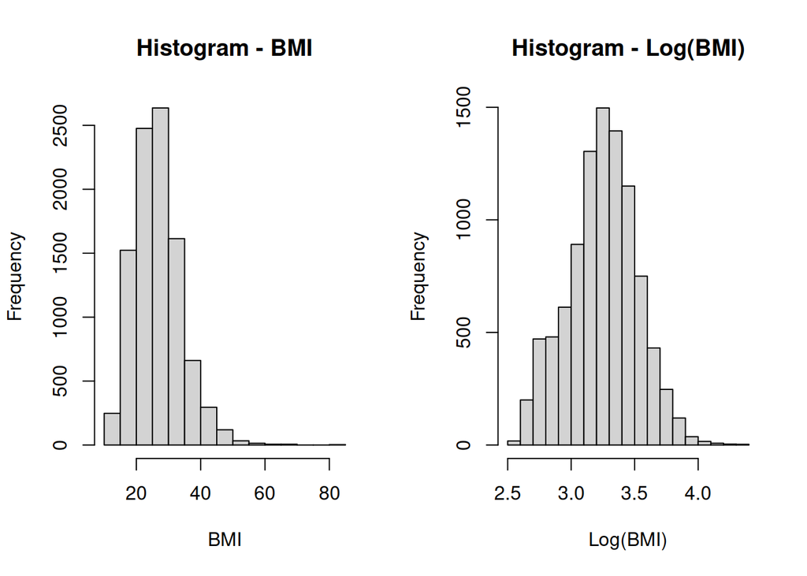

```r
par(mfrow=c(1,2))
hist(NHANES$BMI,
     main = "Histogram - BMI",
     xlab = "BMI")
hist(log(NHANES$BMI),
     main = "Histogram - Log(BMI)",
     xlab = "Log(BMI)")
```

BPSysAve

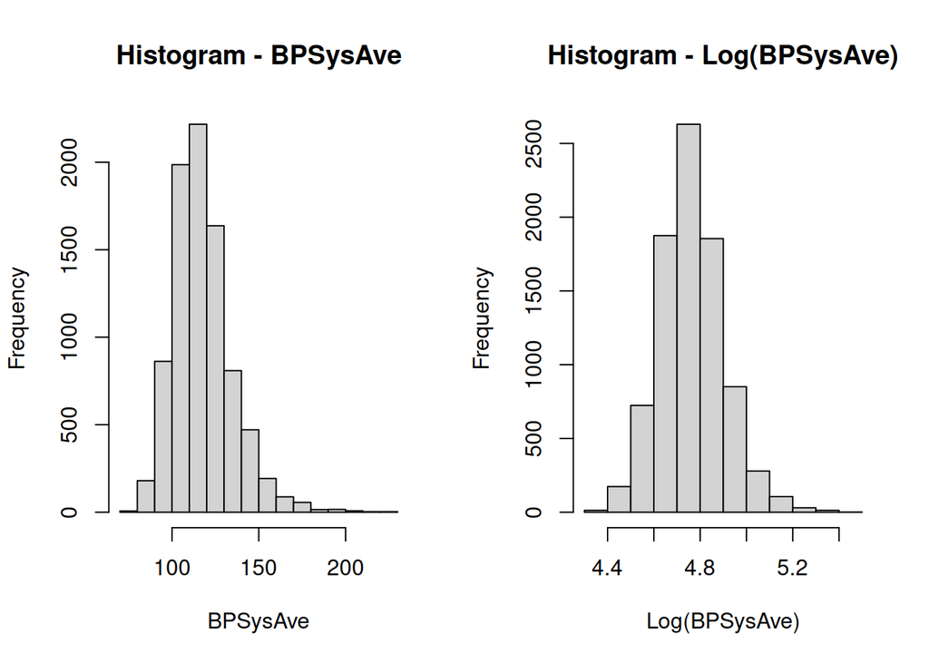

```r
par(mfrow=c(1,2))
hist(NHANES$BPSysAve,
     main = "Histogram - BPSysAve",
     xlab = "BPSysAve")
hist(log(NHANES$BPSysAve),
     main = "Histogram - Log(BPSysAve)",
     xlab = "Log(BPSysAve)")
```

BPDiasAve

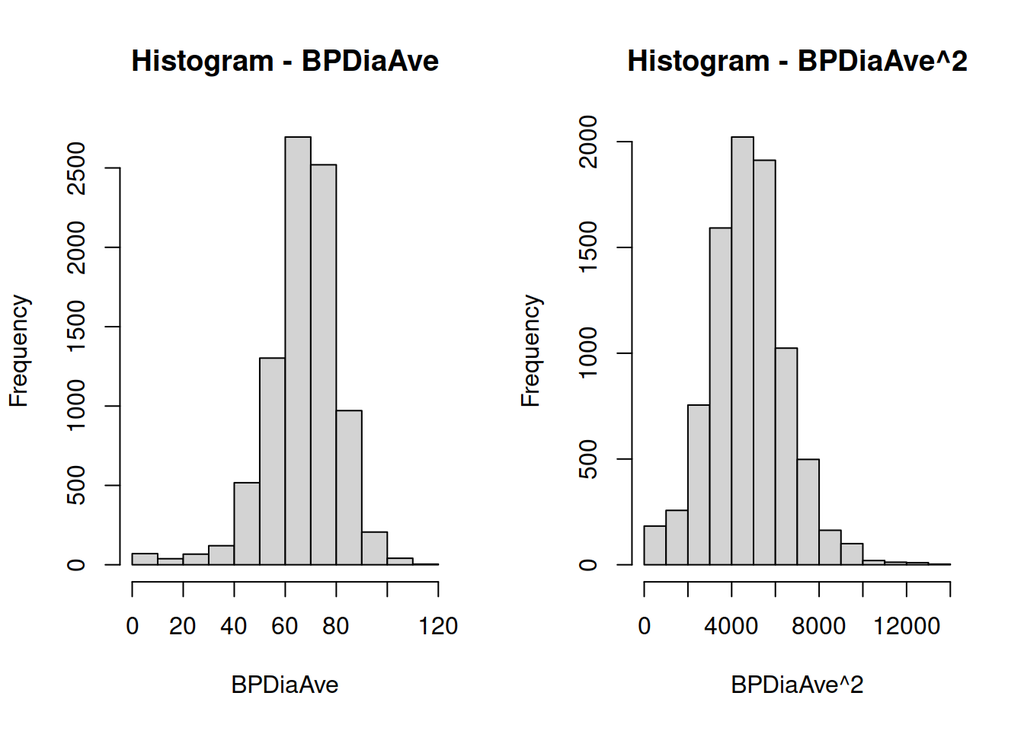

```r
par(mfrow=c(1,2))
hist(NHANES$BPDiaAve,
     main = "Histogram - BPDiaAve",
     xlab = "BPDiaAve")
hist((NHANES$BPDiaAve)^2,
     main = "Histogram - BPDiaAve^2",
     xlab = "BPDiaAve^2")
```

TotChol

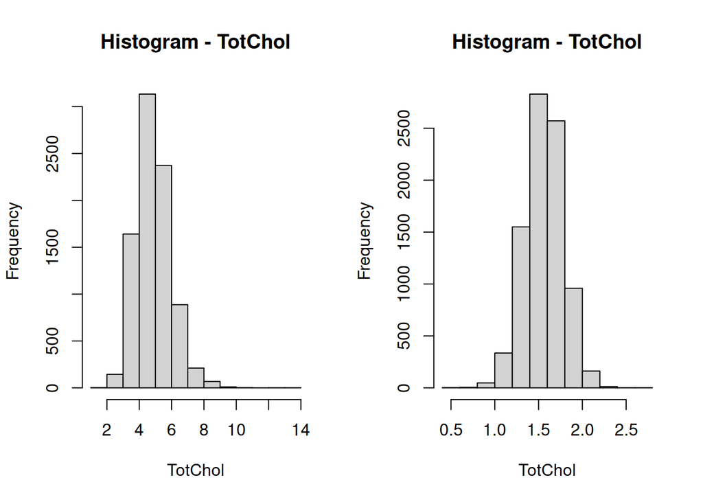

```r
par(mfrow=c(1,2))
hist(NHANES$TotChol,
     main = "Histogram - TotChol",
     xlab = "TotChol")
hist(log(NHANES$TotChol),
     main = "Histogram - TotChol",
     xlab = "TotChol")
```

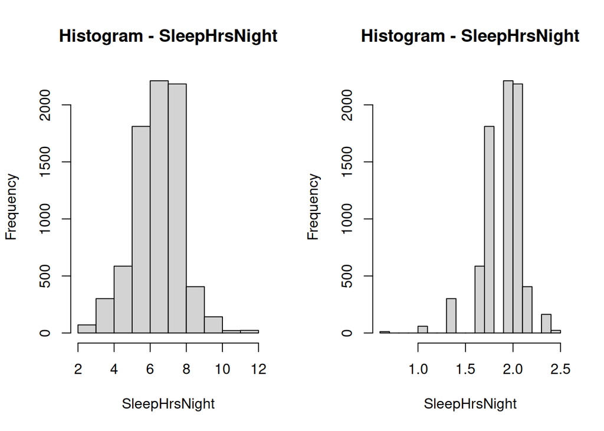

```r
par(mfrow=c(1,2))
hist(NHANES$SleepHrsNight,
     main = "Histogram - SleepHrsNight",
     xlab = "SleepHrsNight")
hist(log(NHANES$SleepHrsNight),
     main = "Histogram - SleepHrsNight",
     xlab = "SleepHrsNight")
```

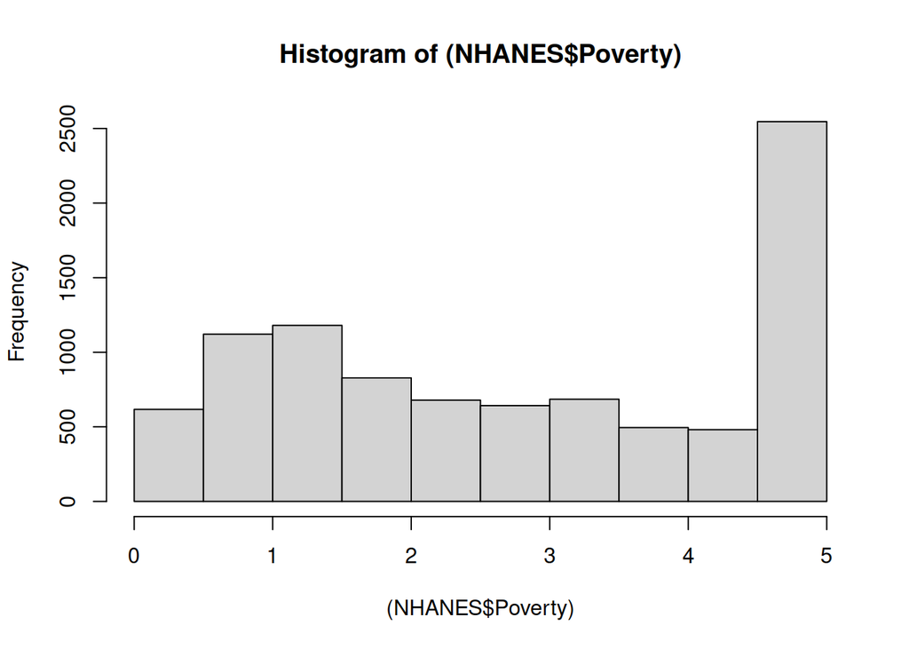

```r
hist((NHANES$Poverty))
```

#### Conclusions

Based on the above findings, we may want to log transform BPSysAve, and TotChol, and consider a square transform of BPDiaAve. I think SleepHrsNight is best left alone, and I do not know what to make of the Poverty levels.